# Plotting

By Nick Cortale

Python has some excellent plotting packages. The two which I use everyday are:

### 1. Matplotlib - [Documentation](http://matplotlib.org)

This is the main plotting package for python. It is capable of producing publication quality plots and can do just about everything. It has a rich history in the python world.

### 2. Seaborn - [Documentation](http://stanford.edu/~mwaskom/software/seaborn/)

Seaborn is what makes your plots pretty. It is extremely easy to use and you can almost just set it and forget it.

This notebook covers some recipes that aren't explicitly talked about in Jake Vanderplas's plotting tutorial which can be found [here](http://www.astro.washington.edu/users/vanderplas/Astr599/notebooks/).

```python
# Import our base packages
import numpy as np
import matplotlib.pyplot as plt
%matplotlib inline
```

Base matplotlib is not the most pleasing to the eye. It is better to simply allow seaborn to take over the styling of the plots. This allows much better looking plots with very minimal effort. As an example of base matplotlib:

```python
x = np.linspace(0,6*np.pi)
y = np.sin(x)
```

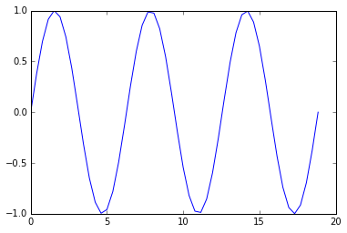

```python
plt.plot(x,y);
```

Now by simply importing seaborn and setting it as the defualt we get a completely looking plot.

```python
import seaborn as sns
sns.set()
```

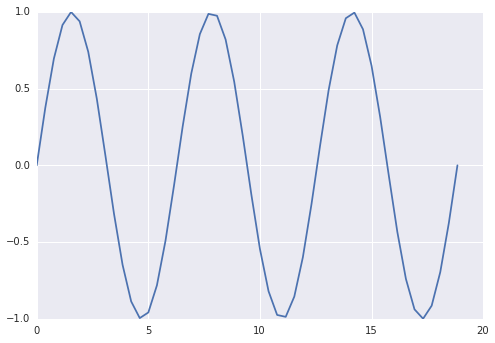

```python
plt.plot(x,y);
```

Seaborn also comes with some simple built in styles that create good looking plots. They are:

1. darkgrid
2. whitegrid
3. dark
4. white
5. ticks

Darkgrid is set as the defualt and is the style of the plot above. Example:

```
sns.set_style('ticks')
```

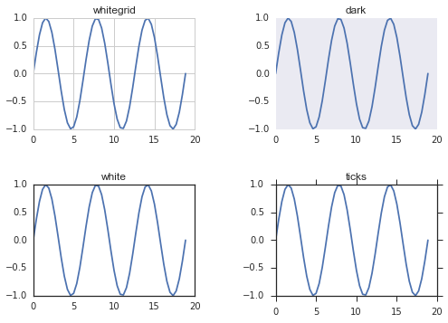

```python
fig = plt.figure()
sns.set_style("whitegrid")
ax1 = fig.add_subplot(2,2,1)
ax1.plot(x,y)
ax1.set_title('whitegrid')

sns.set_style("dark")
ax2 = fig.add_subplot(2,2,2)
ax2.plot(x,y)
ax2.set_title('dark')

sns.set_style("white")
ax3 = fig.add_subplot(2,2,3)
ax3.plot(x,y)
ax3.set_title('white')

sns.set_style("ticks")
ax4 = fig.add_subplot(2,2,4)
ax4.plot(x,y)
ax4.set_title('ticks')

fig.subplots_adjust(hspace=0.5,wspace=0.5)
```

Another useful feature of seaborn is being able to set the context. They give you four choices:

1. Paper
2. Notebook
3. Talk
4. Poster

These affect the size of the graphs. Example:

```
sns.set_context('poster',font_scale=2)
```

## Subplots

Getting good looking subplots is something that I struggled with for a while. Here is one recipe that I feel looks the best. There are tons of other parameters that you could tweak. I would suggest poking around and reading the documentation on each part. Chances are you will need to customize something more than what you see here.

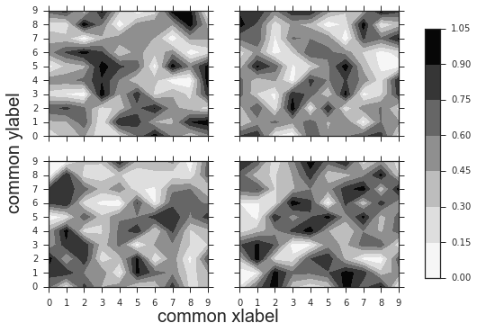

```python
fig, axes = plt.subplots(nrows=2, ncols=2,sharex=True,sharey=True)
for ax in axes.flat:
    im = ax.contourf(np.random.random((10,10)), vmin=0, vmax=1)

# Axis labels
fig.text(0.45, 0.04, 'common xlabel', ha='center', va='center',size=20)
fig.text(0.06, 0.5, 'common ylabel', ha='center', va='center', rotation='vertical',size=20)

# shift them around a little to accomadate a colorbar
fig.subplots_adjust(right=0.8,
                    hspace=0.2, wspace=0.2)

# add Colorbar
cbar_ax = fig.add_axes([0.85, 0.15, 0.03, 0.7])
fig.colorbar(im, cax=cbar_ax);
```

```python
# save figure
#fig.savefig('cats.pdf',bbox_inches='tight');
```

## Colormaps

Seaborn has some good [documentation](http://stanford.edu/~mwaskom/software/seaborn/tutorial/color_palettes.html) on why colormaps are so important. Some of my more favorite colormaps are:

1. 'coolwarm'
2. 'cubehelix'

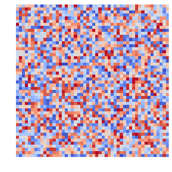

```python
plt.imshow(np.random.rand(50,50),interpolation='none',cmap='coolwarm')
plt.axis('off');
```

You can also use many of the seaborn built in colormaps. They have some pretty cool looking stuff.

```python
colormap = sns.cubehelix_palette(8, as_cmap=True)
```

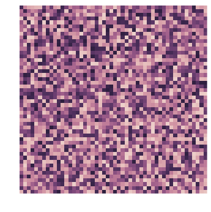

```python
plt.imshow(np.random.rand(50,50),interpolation='none',cmap=colormap)
plt.axis('off');
```

And that is about it for now. I will probably be adding to this as I find more useful recipes.